# Visualize Data: The Basics

# 1 Introduction to Data Visualization

Data visualization is the first step in data exploration and is also a great place to start off when learning `R` because it can be very satisfying when learning to code - “*I want to make a plot, and I did it!*! We will be using the `ggplot2` package. This is one of the earliest packages in the `tidyverse` and it implements the”grammar of graphics", which is a logical system for describing and building graphs.

# 2 The Basics Part 1

- Mappings and aesthetics
- Facets
- Geoms
- Stat
- Position
- Global vs Local settings

“r setup” is an optional label for a chunk, but it should always run once before anything else. Notice that in this setup we are loading the `tidyverse` and `here` packages.

```r
library(tidyverse)
library(here)
```

The `wq` data frame contains monthly averages of water quality data (e.g., temperature, salinity, dissolved oxygen, etc.) from six National Estuarine Research Reserves in the contiguous United States. *Notice the use of the `here` package in the code below.*

```r
wq <- read.csv(here::here('data', 'monthly_wq.csv'))
```

**Tip**: Always be sure to check your data. You can use `head()`, `tail()`, or `str()` from the base package in `R`. Or one of our favorite quick an easy ways is `glimpse()`, which is a great all in one snapshot of the data.

**Quick Quiz**

What relationship do you expect to see between temperature (temp) and dissolved oxygen (do_mgl)?

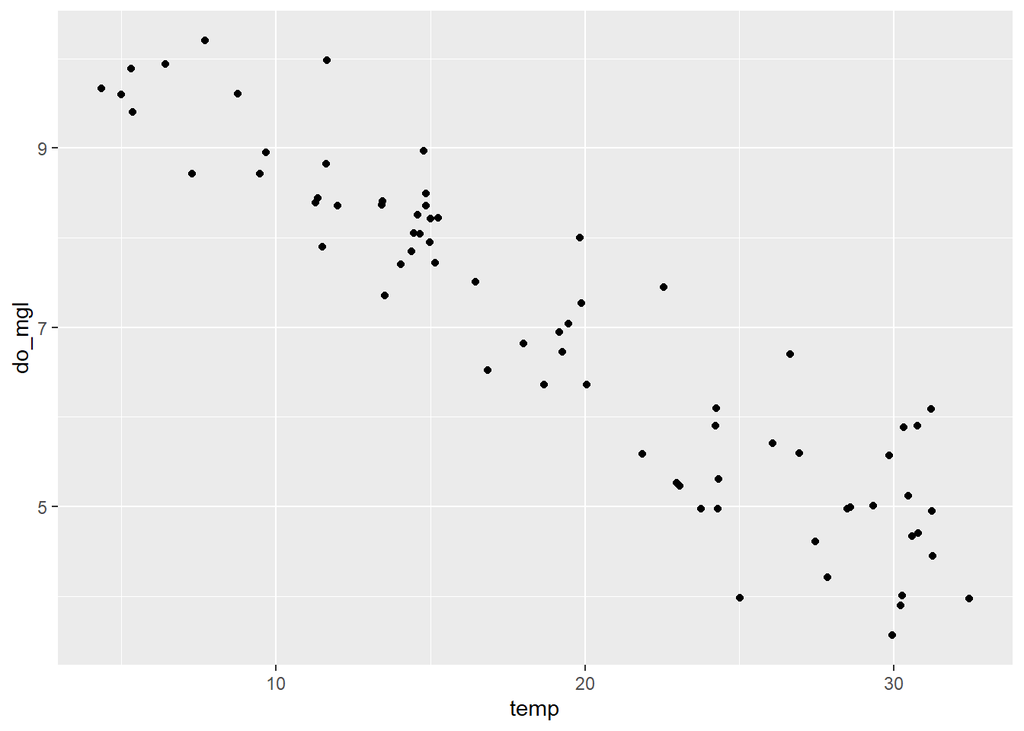

```r
ggplot(data = wq) +
    geom_point(mapping = aes(x = temp, y = do_mgl))
```

There are two main parts to this scatterplot:

1. Initialize the figure with `ggplot()`. This creates a coordinate system for which you can then add subsequent layers. The first argument of this function is the dataset to use in the graph, so `ggplot(data = <DATA>)` creates an empty graph. (*go on, you can try just plotting that*)
2. You add layers with `geom_` functions. Each `geom_` function takes a mapping argument. This is how the variables are defined and mapped to visual properties. The mapping argument is always paired with `aes()` and the x and y arguments of `aes()` specify which variables to map to the x and y axes by looking at the `<DATA>` argument in the initial code.

This gives us the start of a nice template for future work with `ggplot2`:

```r
ggplot(data = <DATA>) +
  <GEOM_FUNCTION>(mapping = aes(<MAPPINGS>))
```

## 2.1 What are Mappings?

**Aesthetics** are the visual properties of the objects in your plot (e.g., color, size, shape, etc.). **Mappings** describe how the aethetics should *relate to variables* in the data.

For example, you could have the points in a scatterplot be colored by their associated “state”. In visual space, we see the colors of each point, but in data space each of these colors represents a data value from the “state” variable.

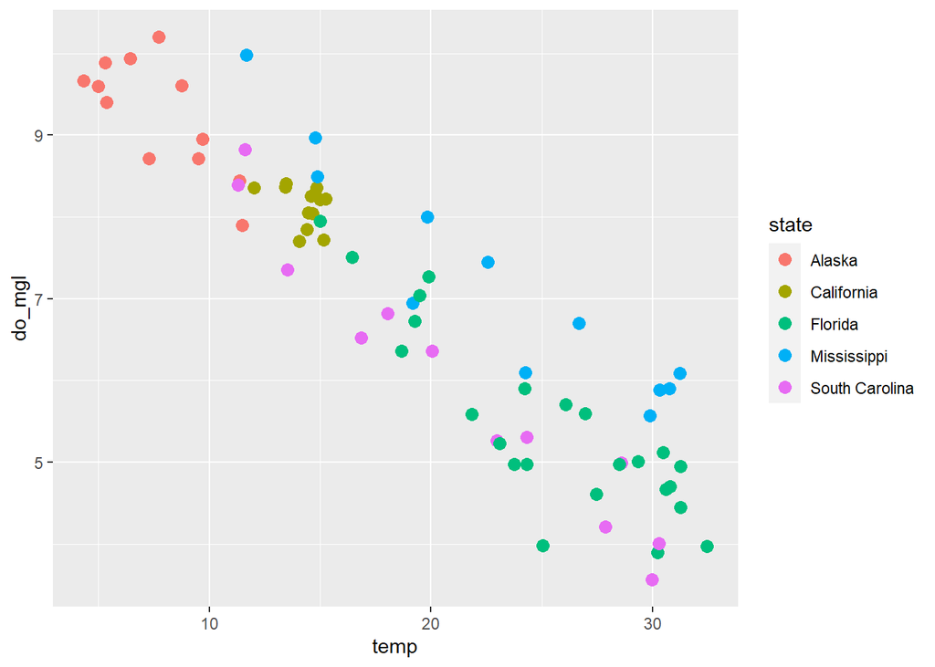

Each geom comes with their own suite of aesthetics that it recognizes. You can use the `?geom_<insert>` function to explore the associated aesthetics for each geom.

You can also set the aesthetic properties of a geom manually, but be careful when doing so. Anything within the `aes()` call maps an aesthetic to a variable. This means that `R` will be looking for that variable and the data associated within it in order to create the plot. Outside of the `aes()` call, maps an aesthetic to a value. As an example, run the two lines of code below.

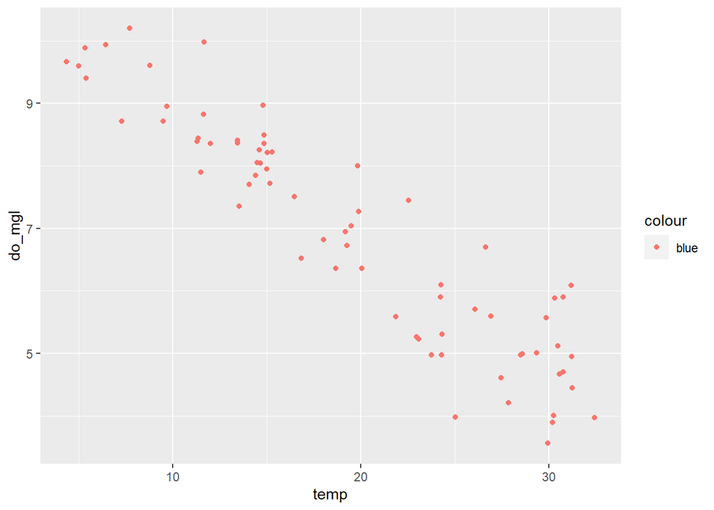

```r
ggplot(wq) +
    geom_point(aes(x = temp, y = do_mgl, color = "blue"))
```

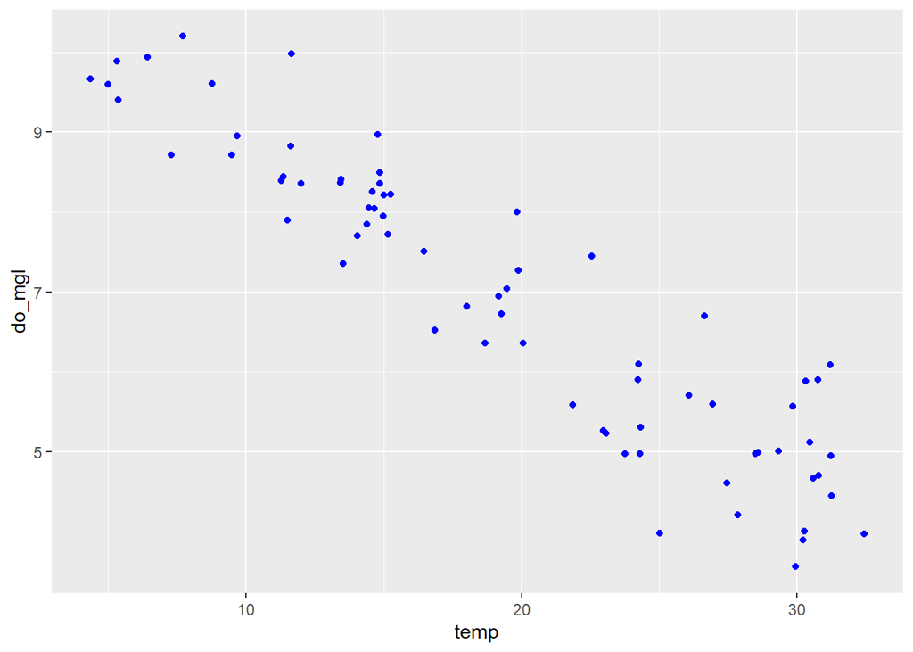

```r
ggplot(wq) +
    geom_point(aes(x = temp, y = do_mgl), color = "blue")
```

What did you notice about the two plots?

## 2.2 Facets

What if you don’t want to add additional variables as aesthetics? If they are categorical variables, you can use **facets**! Facets create subplots that each display one subset of the data. There are two types of facets in `ggplot2`: `facet_wrap()` and `facet_grid()`.

If you only have a single variable, it’s best to use `facet_wrap()`. If you have a combination of two variables, use `facet_grid()`.

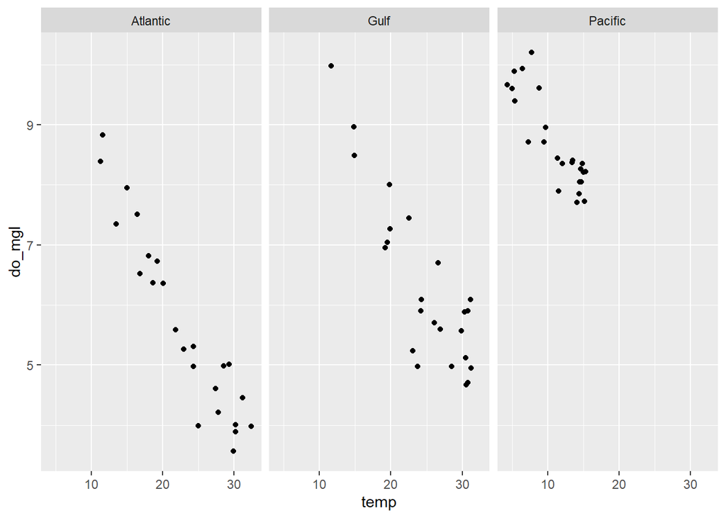

```r
ggplot(data = wq) +
  geom_point(mapping = aes(x = temp, y = do_mgl)) +
  facet_wrap(~ coast, nrow = 1)
```

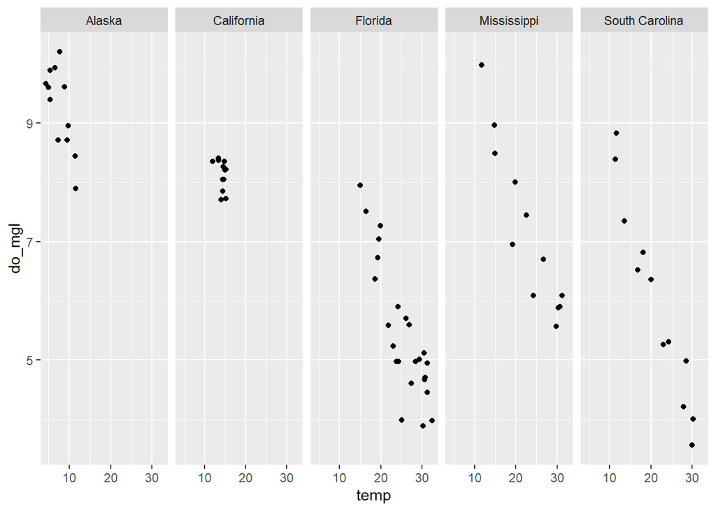

```r
ggplot(data = wq) +
  geom_point(mapping = aes(x = temp, y = do_mgl)) +
  facet_grid(. ~ state)
```

What did the period do in the `facet_grid()` example?

## 2.3 Geoms

### 2.3.1 Basics

The geometric object (‘geom’) is the visual object used to represent the data. Two plots may share all the same data, but in using different geometric objects, the visual representation of the data will appear a little different. Take the following plots for example:

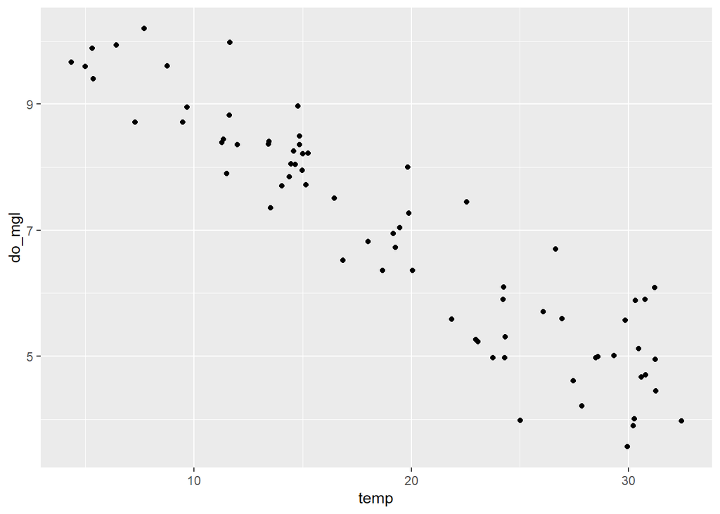

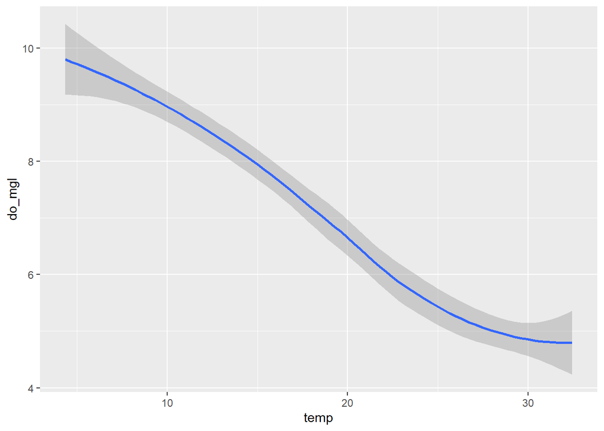

Notice how both plots have the same x and y variables as well as the data - they just have different visual objects (one is a scatterplot, the other is a smoothed plot).

Every geom requires a mapping argument and they each come with their own suite of acceptable aesthetics. You can find the list of available aesthetics for each geom within their help file or even by using the `ggplot2` cheatsheet from RStudio.

#### 2.3.1.1 Example 1

Replace this scatterplot with one that draws boxplots.

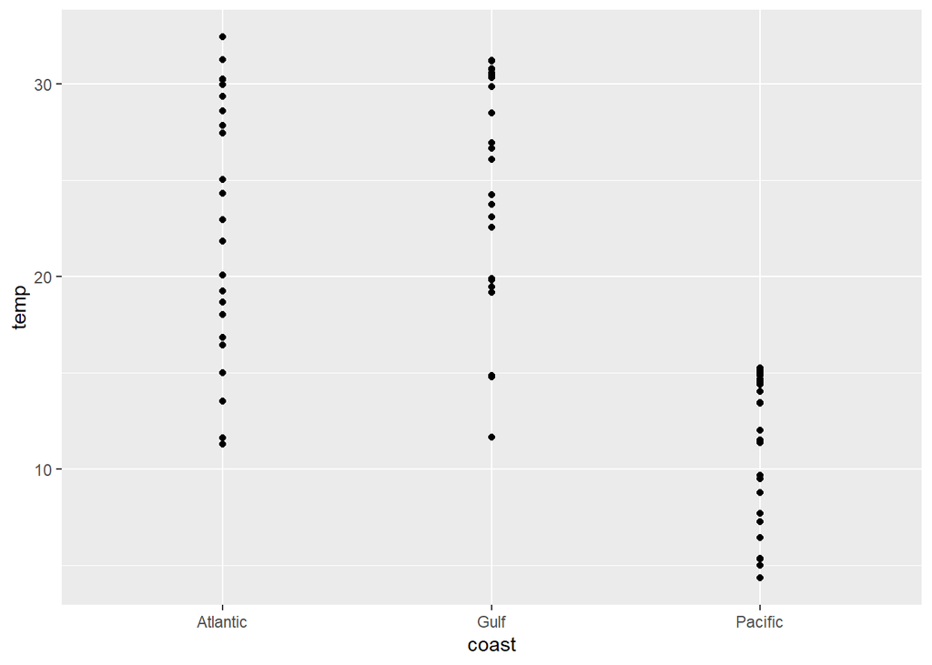

```r
# scatterplot
ggplot(data = wq) +
  geom_point(mapping = aes(x = coast, y = temp))
```

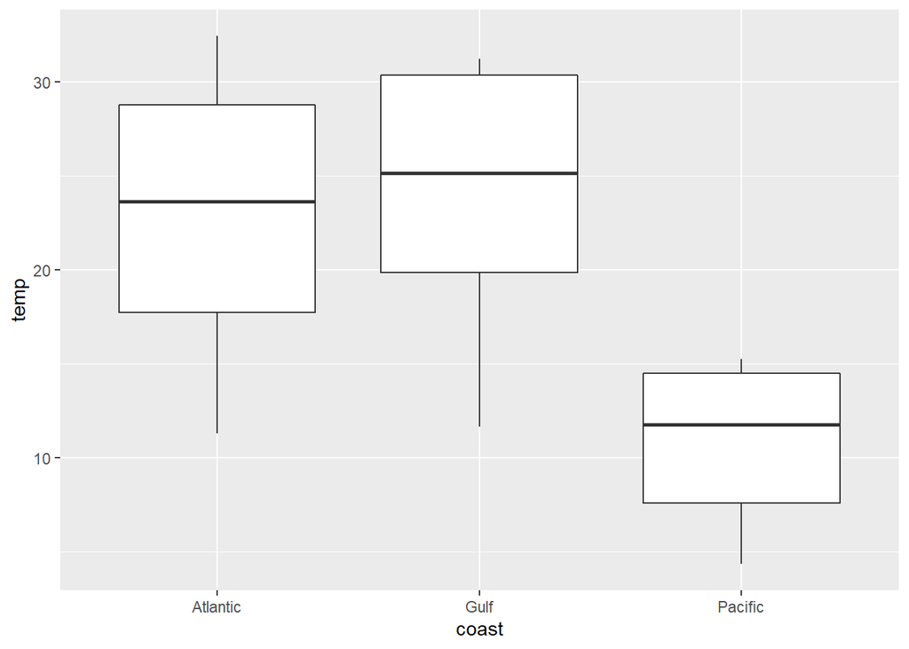

```r
# boxplot
ggplot(data = wq) +
  geom_boxplot(mapping = aes(x = coast, y = temp))
```

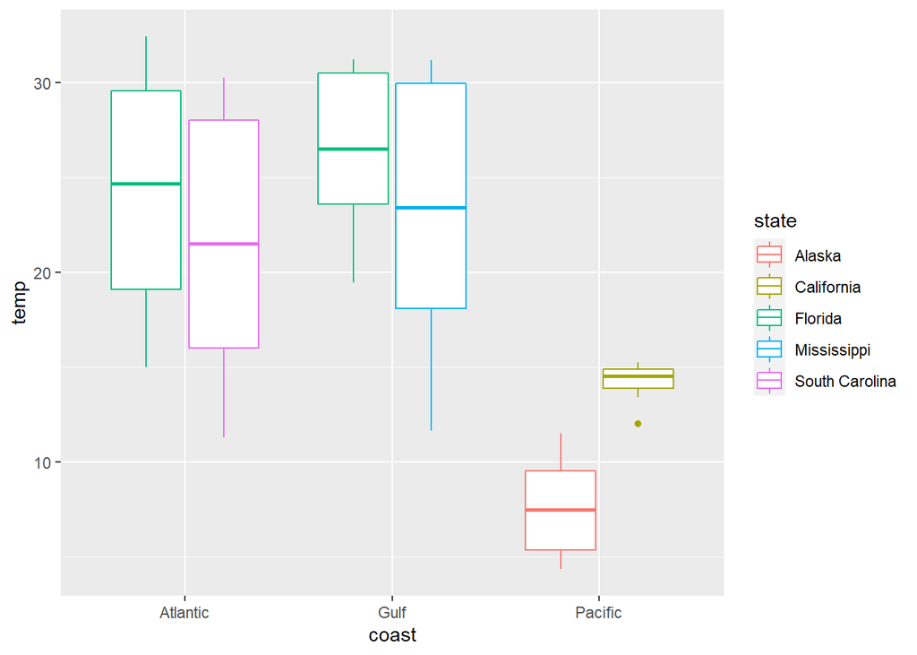

```r
# geom_boxplot also has aesthetics you can map
ggplot(data = wq) +
  geom_boxplot(mapping = aes(x = coast, y = temp, color = state))
```

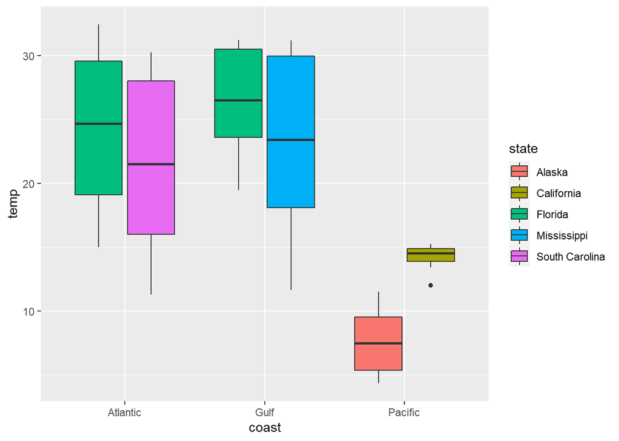

```r
ggplot(data = wq) +
  geom_boxplot(mapping = aes(x = coast, y = temp, fill = state))
```

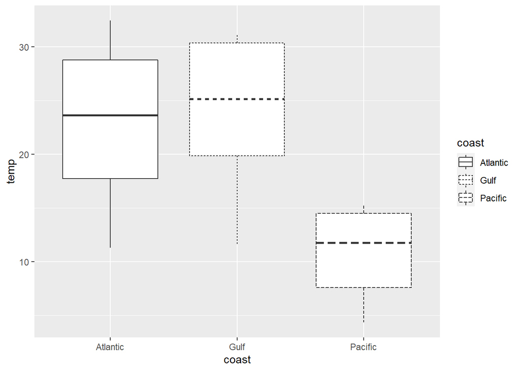

```r
ggplot(data = wq) +
  geom_boxplot(mapping = aes(x = coast, y = temp, linetype = coast))
```

Let’s check out another dataset called `diamonds`. This data set contains prices and other attributes of diamonds and is provided by the `ggplot2` package - so we do not need to load it like we did the water quality dataset.